# Reproducible Research: Peer Assessment 1

## Loading and preprocessing the data

Assuming that the data file `activity.zip` has been saved in working directory.

```r
unzip("activity.zip")
activity <- read.csv("activity.csv", header = TRUE, na.strings = "NA")
```

## What is mean total number of steps taken per day?

Group the data by date and store the total number of steps taken each day in a new column `total.steps`

```r
library(dplyr)
library(lubridate)
activity$date <- ymd(activity$date)
by.day <- activity %>%
  group_by(date) %>%
  summarise(total.steps = sum(steps, na.rm = TRUE))
```

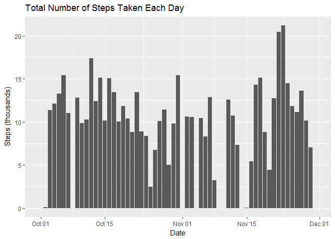

```r
library(ggplot2)
with(by.day, qplot(date, total.steps, geom = "col") +
       xlab("Date") + ylab("Steps (thousands)") +
       labs(title = "Total Number of Steps Taken Each Day") +
       scale_y_continuous(labels = function(x) { x / 1000;}))
```

The mean and median total number of steps taken per day can easily be found using the `summary` function:

```r
summary(by.day$total.steps)
```

```
##    Min. 1st Qu.  Median    Mean 3rd Qu.    Max.
##       0    6778   10395    9354   12811   21194
```

## What is the average daily activity pattern?

Transform the data and plot the average number of steps for each 5-minute interval (averaged across all days).

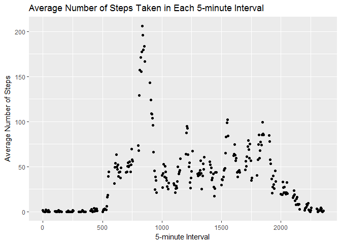

```r
library(dplyr)
by.interval <- activity %>%
  group_by(interval) %>%
  summarise(avg.steps = mean(steps, na.rm = TRUE))

with(by.interval, qplot(interval, avg.steps) +
       xlab("5-minute Interval") + ylab("Average Number of Steps") +
       labs(title = "Average Number of Steps Taken in Each 5-minute Interval"))
```

The following code will find the 5-minute interval with maximum number of average steps:

```r
max.interval <- by.interval[which.max(by.interval$avg.steps),1]
max.interval
```

```
## # A tibble: 1 x 1
##   interval
##      <int>
## 1      835
```

On average, interval 835 contains the maxinum number of steps.

## Imputing missing values

Find the total number of missing values in data set:

```r
missing.rec <- sum(is.na(activity$steps))
missing.rec
```

```
## [1] 2304
```

There are 2304 missing values in the dat set.

For missing data in a particular time interval, we can fill in with the average number of steps for that interval:

```r
new.act <- activity
for (i in seq_len(nrow(new.act))) {
  if (is.na(new.act[i,]$steps)) {
    interval <- new.act[i,]$interval
    new.act[i,]$steps <- by.interval[by.interval$interval == interval,]$avg.steps
  }
}
```

Now we re-create the plot of daily steps taken with missing data filled in.

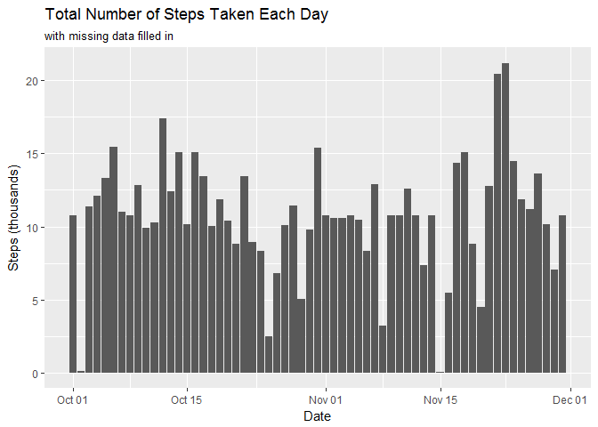

```r
new.by.day <- new.act %>%
  group_by(date) %>%
  summarise(total.steps = sum(steps, na.rm = TRUE))

with(new.by.day, qplot(date, total.steps, geom = "col") +
       xlab("Date") + ylab("Steps (thousands)") +
       labs(title = "Total Number of Steps Taken Each Day",
            subtitle = "with missing data filled in ") +
       scale_y_continuous(labels = function(x) { x / 1000;}))
```

With missing data filled in, the mean and median of the total numberof steps taken each day can be calculated as:

```r
summary(new.by.day$total.steps)
```

```
##    Min. 1st Qu.  Median    Mean 3rd Qu.    Max.
##      41    9819   10766   10766   12811   21194
```

These values are different from those calculated with missng data. Imputing missin values increases both the mean and median of the total number of steps taken each day.

## Are there differences in activity patterns between weekdays and weekends?

Add a column to the data set

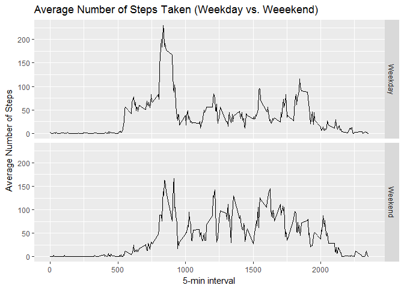

```r
# the code below assumes that current locale is English_US
new.act$wday <- "weekday"
new.act[weekdays(new.act$date, TRUE) %in% c("Sat", "Sun"),]$wday <- "weekend"
new.act$wday <- factor(new.act$wday, levels = c("weekday", "weekend"),
                       labels = c("Weekday", "Weekend"))
new.act.grp <- new.act %>%
  group_by(wday, interval) %>%
  summarise(avg.step = mean(steps))

with(new.act.grp, qplot(interval, avg.step, facets = wday~., geom = "line") +
       xlab("5-min interval") + ylab("Average Number of Steps") +
       labs(title = "Average Number of Steps Taken (Weekday vs. Weeekend)"))
```